# 206 Assignment 4

Part 3. Changes in lobster size at MPA and non-MPA sites (comparing only 2012 and 2017 sizes) - 1. Exploratory data analysis - Summary data table with size means within MPA sites during 2012 and 2017 - Summary data table with size within non-MPA sites during 2012 and 2017 - Histograms and QQplots for MPA and Non-MPA sites (2012-2017) - 2. Hypothesis test for size change in MPA sites during 2012 and 2017 - Null Hypothesis – there is no significant difference in carapace length (2012 and 2017) - Alternative Hypothesis – there IS a significant difference in carapace length (2012 and 2017) - 3. Hypothesis test for size change in non-MPA sites during 2012 and 2017 - Null Hypothesis – there is no significant difference in carapace length between 2012 and 2017 - Alternative Hypothesis – there IS a significant difference in carapace length (2012-2017) - 4. Hypothesis test to compare carapace length between MPA sites and non-MPA sites during 2012 (and separately 2017) - Null Hypothesis – there is no significant difference in carapace length of lobsters in MPA sites and non-MPA sites - Alternative Hypothesis – there IS no significant difference in carapace length of lobsters in MPA sites and non-MPA sites

```
## # A tibble: 2 x 6
##    YEAR mean_size median_size max_size sd_size `length(SIZE)`
##   <int>     <dbl>       <dbl>    <dbl>   <dbl>          <int>
## 1  2012      67.4        64.5      105    12.2             32
## 2  2017      72.2        72        150    14              718
```

```
## # A tibble: 2 x 6
##    YEAR mean_size median_size max_size sd_size `length(SIZE)`
##   <int>     <dbl>       <dbl>    <dbl>   <dbl>          <int>
## 1  2012      74.9          75      156    12.4            199
## 2  2017      72.3          73      115    12.5            950
```

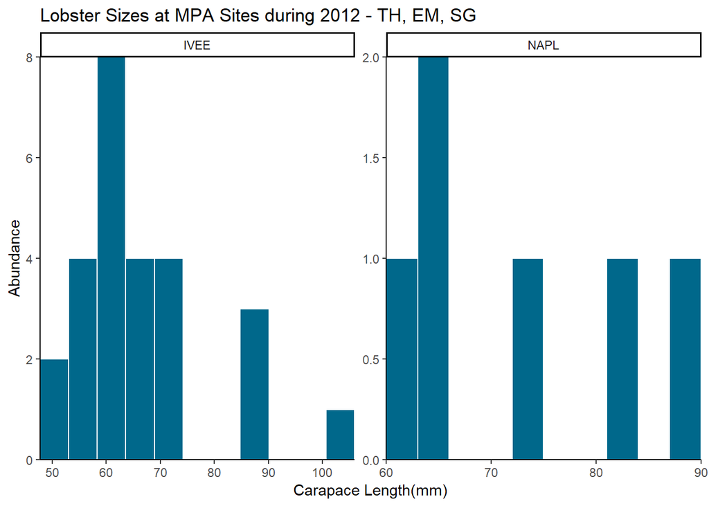

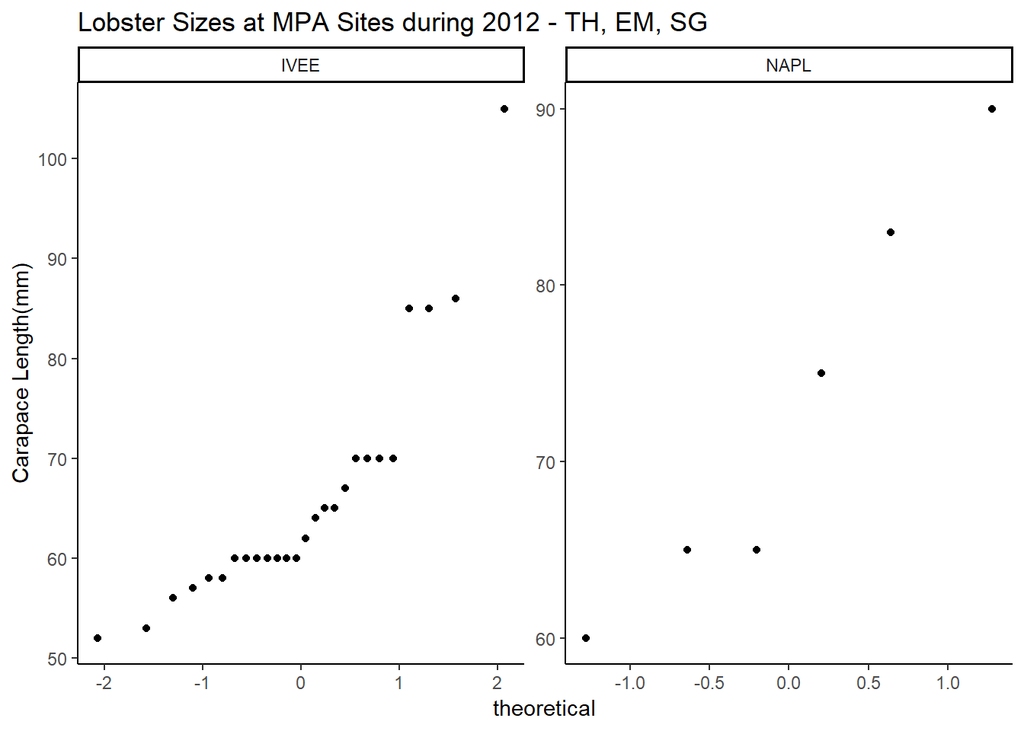

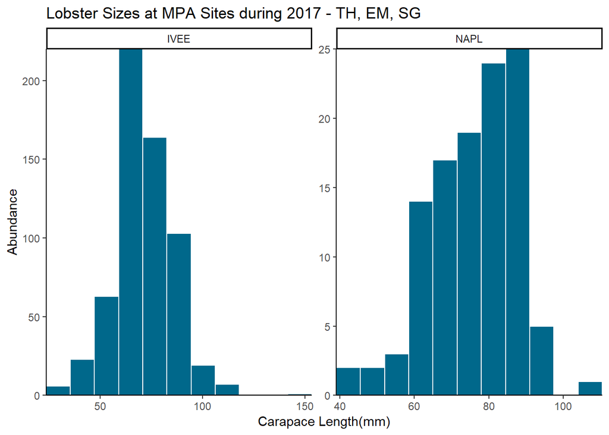

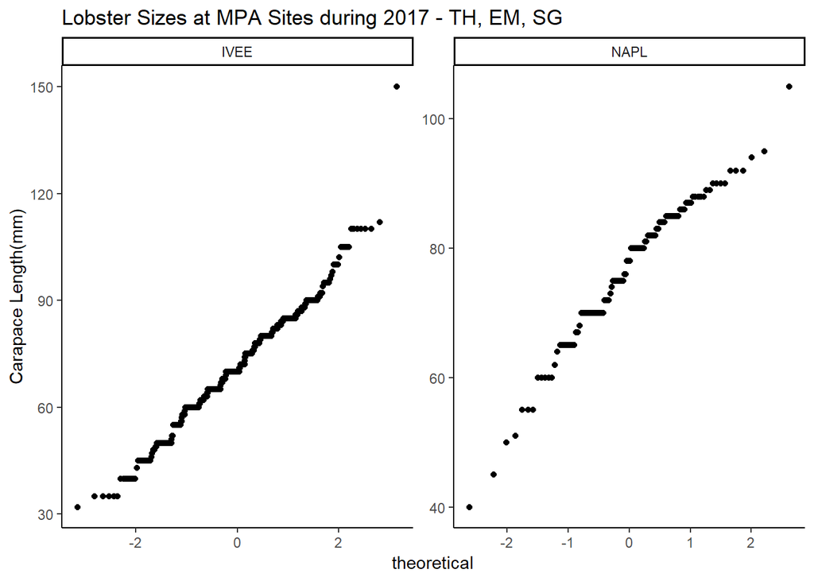

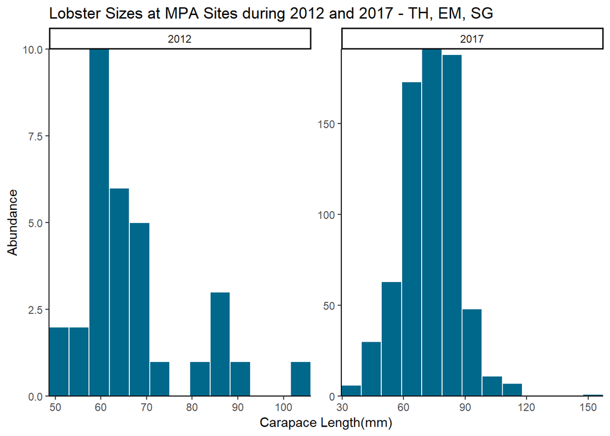

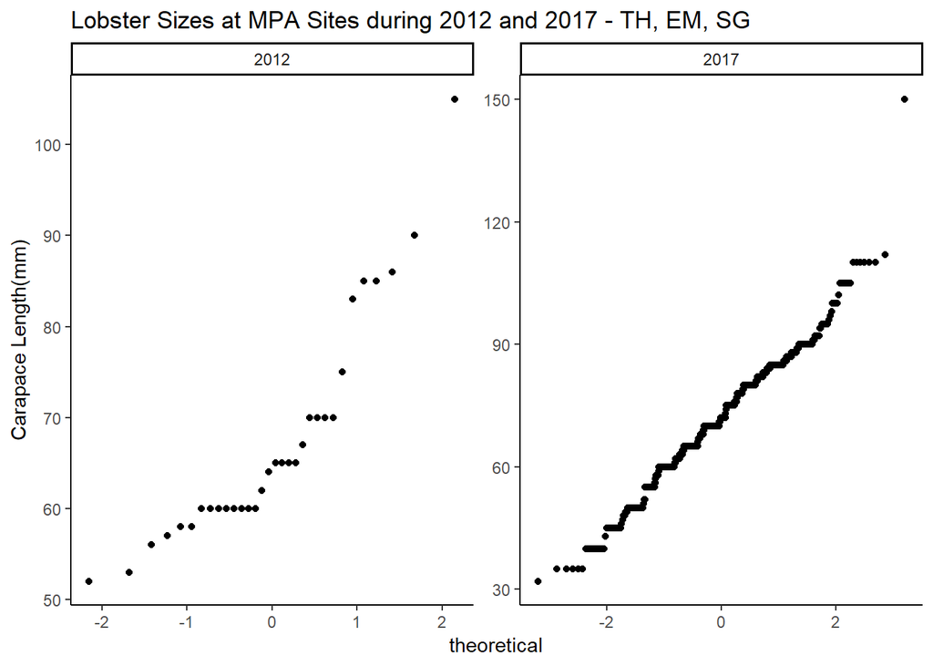

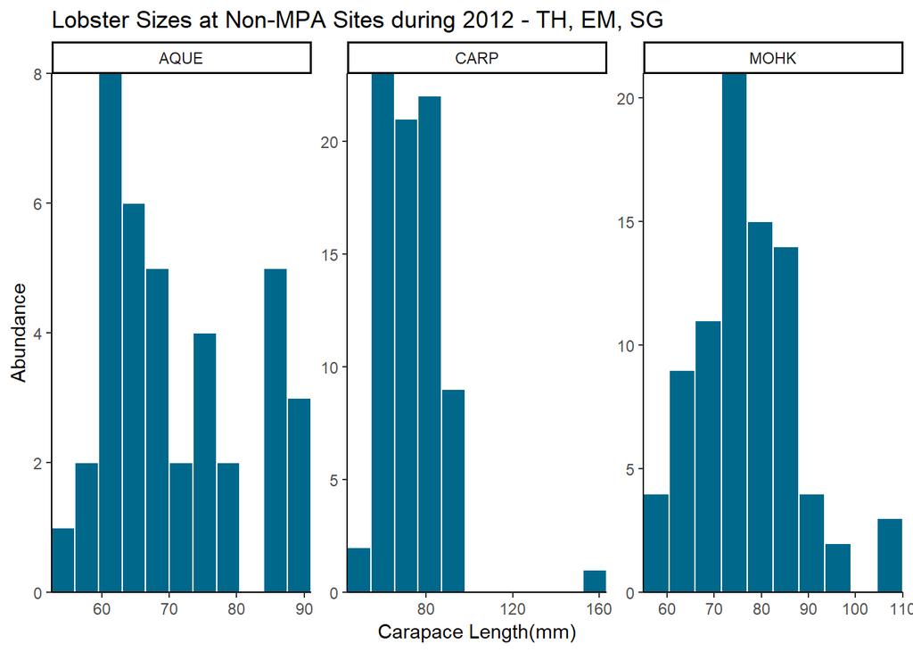

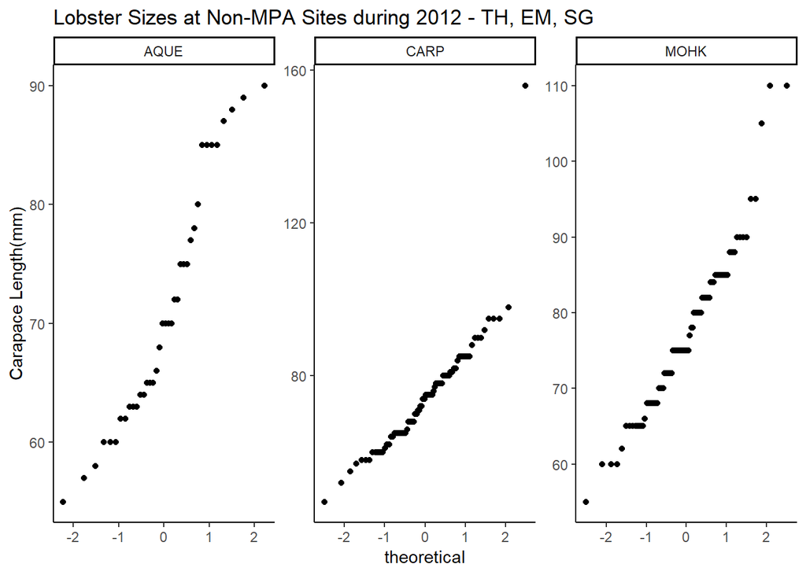

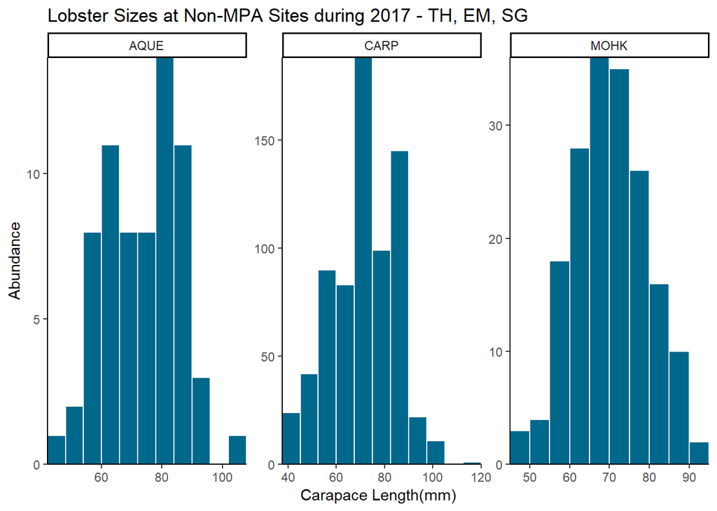